# LPAIV-infected and uninfected control groups - Bursa - Gene

Jared J. Homola

29 October, 2020

This is an analysis of differential expression at the gene level between treatment groups for control and infected blue-winged teal bursa samples.

```r
## Load packages and data
library(limma)
library(edgeR)
library(Glimma)
library(gplots)
library(ggrepel)
library(RColorBrewer)
library(gridExtra)
library(kableExtra)
library(topGO)
library(tidyverse)

## Load data
annot <- read.delim("G:/Shared drives/RNA Seq Supershedder Project/BWTE DE manuscript/extData/Trinotate.csv", header = TRUE, sep = "\t")
cnt <- read.table("G:/Shared drives/RNA Seq Supershedder Project/BWTE DE manuscript/extData/rsem.gene.counts.matrix", header = TRUE)
covars <- read.csv("G:/Shared drives/RNA Seq Supershedder Project/BWTE DE manuscript/extData/BWTE54_SSgroup_Raw_Pool.csv", header = TRUE)
```

### Clean data

Bird 36 is missing a measurement for the weight covariate and bird 19 had improper tissue-based grouping, suggesting a potential sample mix up. They are both removed from the analysis. We also rename the genes, dropping the “Trinity_” prefix.

```r
cnt <- cnt %>%
  select(
    -alignEstimateAbundance_BWTE_Ileum_36_S50,
    -alignEstimateAbundance_BWTE_Bursa_36_S31,-alignEstimateAbundance_BWTE_Ileum_19_S35,
    -alignEstimateAbundance_BWTE_Bursa_19_S14) %>%
  rownames_to_column("gene") %>%
  separate(gene, into = c(NA, "pt1", "pt2", "gene")) %>%
  unite(gene, pt1, pt2, gene) %>%
  column_to_rownames("gene") %>%
  select(contains("Bursa"))

covars <- covars %>%
  filter(!bird %in% c("36", "19")) %>%
  arrange(bird) %>%
  mutate(group = str_remove(group, "-"))

annot <- annot %>%
  separate(transcript_id, into = c(NA, "pt1", "pt2", "gene", "isoform")) %>%
  unite(transcript_id, pt1, pt2, gene, isoform) %>%
  separate(gene_id, into = c(NA, "pt1", "pt2", "gene")) %>%
  unite(gene_id, pt1, pt2, gene)
```

### Set up model effects

```r
bird <- as.factor(covars$bird)
sex <- as.factor(covars$sex)
age <- as.numeric(covars$age)
weight <- covars$wt_55
group <- recode(covars$group, C1 = "Ctl", C14 = "Ctl") %>%
  as.factor()
pool <- as.factor(covars$Pool.Bursa)
```

### Prep data for analysis

Here we standardize expression levels across samples of varying depth by using the counts per million (CPM) and trimmed mean of M-values (TMM) methods. We also remove any genes that are expressed at few than 0.5 CPM in at least 25% of individuals.

```r
#Convert to DGEList object
dge <- DGEList(counts=cnt)
dge$genes <- annot[match(rownames(dge$counts), annot$gene_id),]

#CPM and log-CPM
cpm <- cpm(dge)
lcpm <- cpm(dge, log = TRUE)

#### Retain only genes expressed at >0.5 CPM in at least 25% of individuals
table(rowSums(dge$counts==0) == length(cnt[1,]))
```

```
##
##  FALSE   TRUE
## 368495  81461
```

```r
keep.exprs <- rowSums(cpm>0.5) >= length(cnt[1,])/4
sum(keep.exprs)
```

```
## [1] 75290
```

```r
dge <- dge[keep.exprs,, keep.lib.sizes=FALSE]
table(rowSums(dge$counts==0) == length(cnt[1,]))
```

```
##
## FALSE
## 75290
```

```r
dim(dge)
```

```
## [1] 75290    52
```

```r
#TMM normalization
dge <- calcNormFactors(dge, method = "TMM")
```

### Plot MDS

Multidimensional scaling (MDS) plots are an ordination technique that lets us examine sample clustering based on overall gene expression levels.

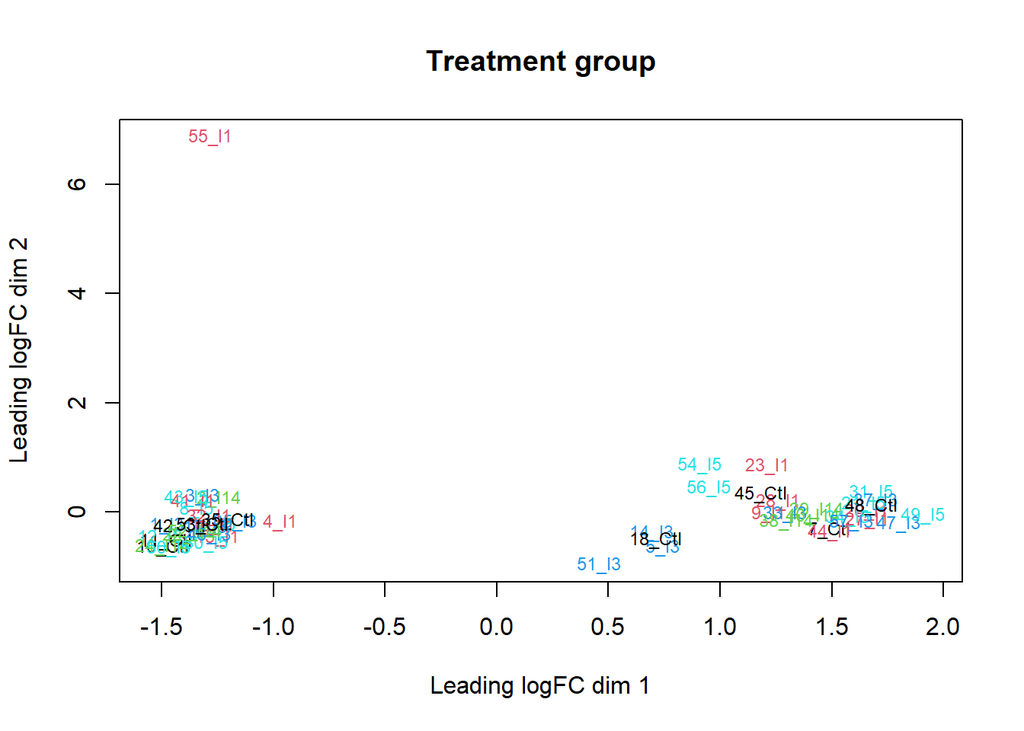

```r
col.group = as.numeric(as.factor(paste0(group)))
plotMDS(lcpm, labels = paste0(bird, "_", group), col = col.group, cex = 0.75)
title(main="Treatment group")
```

# Differential expression analysis

### Establish design & contrast matrices

```r
## Establish design matrix
design = model.matrix(~ 0 +
                        group +
                        age +
                        sex +
                        weight +
                        pool)

colnames(design) <- gsub("group", "", colnames(design))

contr.matrix = makeContrasts(
  CtlvI1 = Ctl - I1,
  CtlvI3 = Ctl - I3,
  CtlvI5 = Ctl - I5,
  CtlvI14 = Ctl - I14,
  I1vI3 = I1 - I3,
  I3vI5 = I3 - I5,
  I5vI14 = I5 - I14,
  levels = colnames(design))
```

### Mean-variance trend and sample weight plots

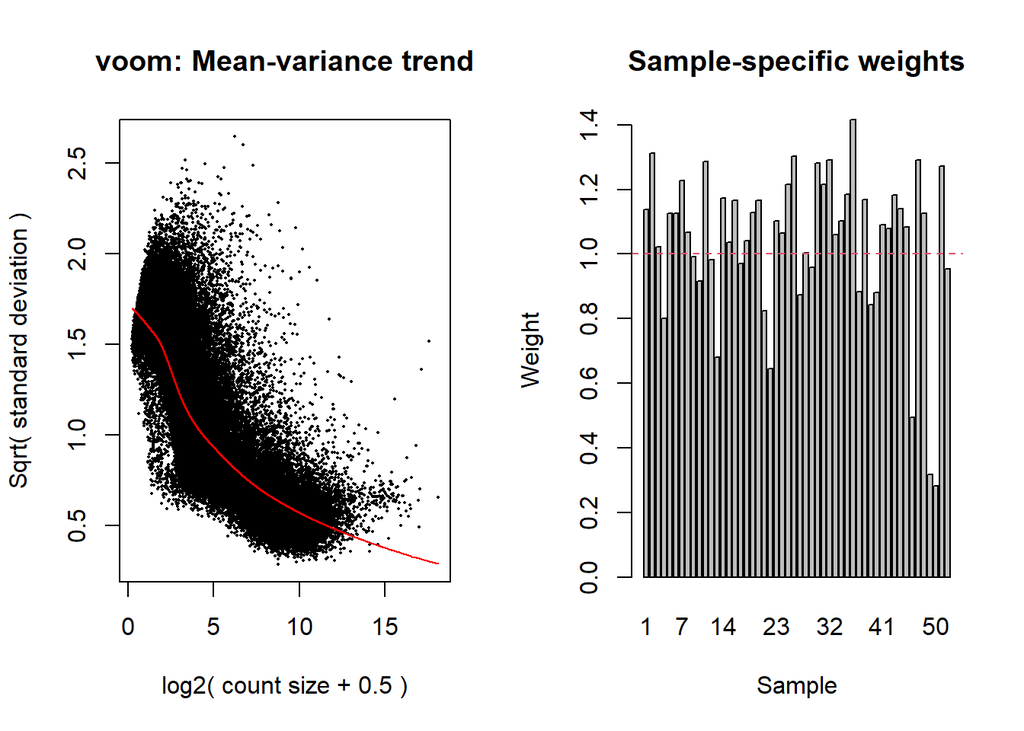

```r
v <- voomWithQualityWeights(dge, design, plot = TRUE)
```

### Fitting the model

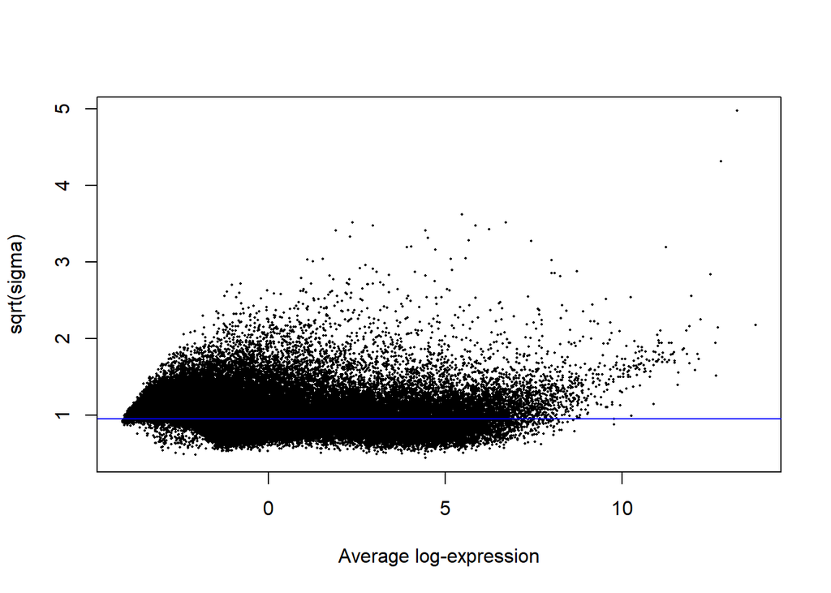

```r
vfit <- lmFit(v, design)
vfit <- contrasts.fit(vfit, contrasts = contr.matrix)
tfit <- treat(vfit, lfc = 1.0)
plotSA(tfit)
```

### Count DE genes

For a gene to be considered differentially expressed, we require a p-value of 0.1 with a false discovery rate correction and a log fold count difference of 1.

```r
dt <- decideTests(tfit, p.value = 0.1, adjust.method = "fdr")
summary(dt) %>%
  kable() %>%
  kable_styling(bootstrap_options = c("striped", "hover", "condensed", "responsive"), full_width = F)
```

|  | CtlvI1 | CtlvI3 | CtlvI5 | CtlvI14 | I1vI3 | I3vI5 | I5vI14 |
| --- | --- | --- | --- | --- | --- | --- | --- |
| Down | 1 | 0 | 0 | 0 | 0 | 0 | 0 |
| NotSig | 75289 | 75290 | 75290 | 75290 | 75290 | 75290 | 75290 |
| Up | 0 | 0 | 0 | 0 | 0 | 0 | 0 |

```r
dt.tib <- as_tibble(dt, rownames = NA) %>%
  rownames_to_column("gene") %>%
  mutate_at(vars(starts_with("C")), as.numeric) %>%
  mutate_at(vars(starts_with("I")), as.numeric) %>%
  filter_at(vars(CtlvI1:I5vI14), any_vars(. != 0))
```

### Histogram of P-values

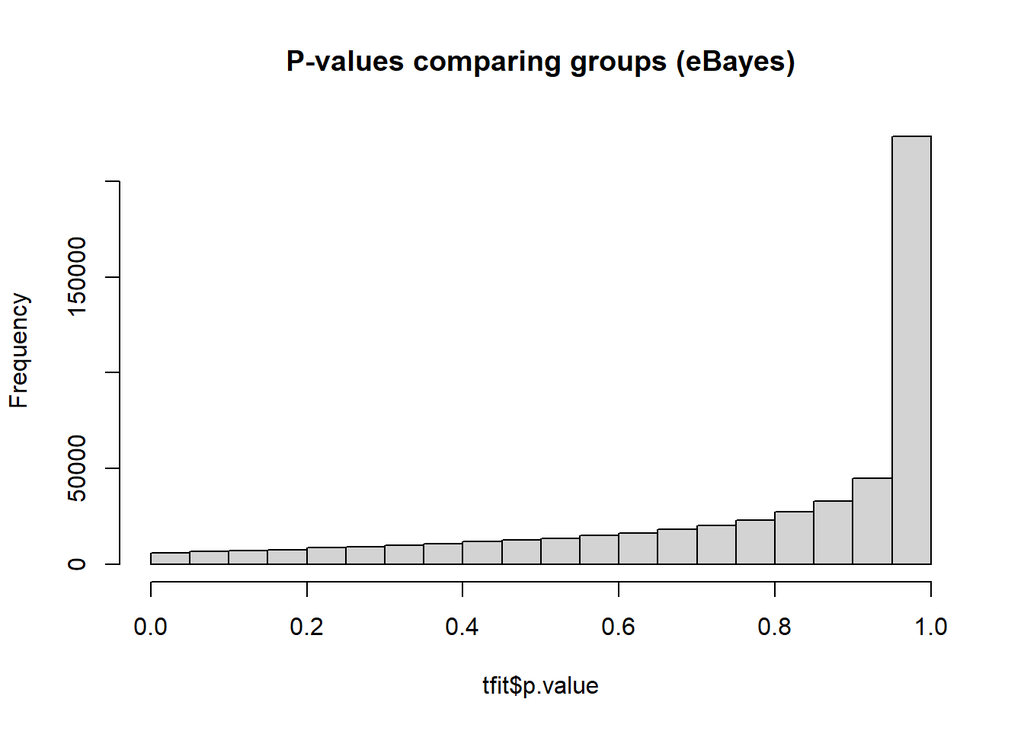

```r
hist(tfit$p.value, main = "P-values comparing groups (eBayes)")
```

### Volcano plot

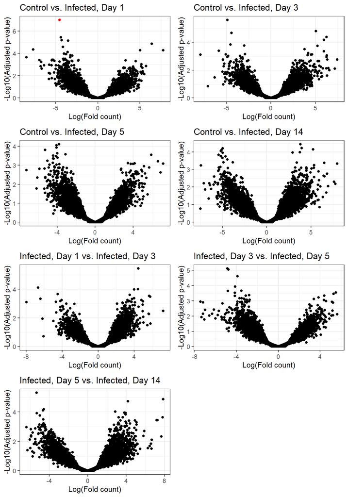

```r
tmp1 <- topTreat(tfit, coef = 1, n = Inf)
results1 <- mutate(tmp1, sig=ifelse(tmp1$adj.P.Val<0.1, "Sig", "Not Sig"))
p1 <- ggplot(results1, aes(logFC, -log10(P.Value))) +
  geom_point(aes(col = sig)) +
  scale_color_manual(values=c("black", "red")) +
  ggtitle("Control vs. Infected, Day 1") +
  ylab("-Log10(Adjusted p-value)") +
  xlab("Log(Fold count)") +
  theme_bw() +
  theme(legend.position = "none")

tmp2 <- topTreat(tfit, coef = 2, n = Inf)
results2 <- mutate(tmp2, sig=ifelse(tmp2$adj.P.Val<0.1, "Sig", "Not Sig"))
p2 <- ggplot(results2, aes(logFC, -log10(P.Value))) +
  geom_point(aes(col = sig)) +
  scale_color_manual(values=c("black", "red")) +
  ggtitle("Control vs. Infected, Day 3") +
  ylab("-Log10(Adjusted p-value)") +
  xlab("Log(Fold count)") +
  theme_bw() +
  theme(legend.position = "none")

tmp3 <- topTreat(tfit, coef = 3, n = Inf)
results3 <- mutate(tmp3, sig=ifelse(tmp3$adj.P.Val<0.1, "Sig", "Not Sig"))
p3 <- ggplot(results3, aes(logFC, -log10(P.Value))) +
  geom_point(aes(col = sig)) +
  scale_color_manual(values=c("black", "red")) +
  ggtitle("Control vs. Infected, Day 5") +
  ylab("-Log10(Adjusted p-value)") +
  xlab("Log(Fold count)") +
  theme_bw() +
  theme(legend.position = "none")

tmp4 <- topTreat(tfit, coef = 4, n = Inf)
results4 <- mutate(tmp4, sig=ifelse(tmp4$adj.P.Val<0.1, "Sig", "Not Sig"))
p4 <- ggplot(results4, aes(logFC, -log10(P.Value))) +
  geom_point(aes(col = sig)) +
  scale_color_manual(values=c("black", "red")) +
  ggtitle("Control vs. Infected, Day 14") +
  ylab("-Log10(Adjusted p-value)") +
  xlab("Log(Fold count)") +
  theme_bw() +
  theme(legend.position = "none")

tmp5 <- topTreat(tfit, coef = 5, n = Inf)
results5 <- mutate(tmp5, sig=ifelse(tmp5$adj.P.Val<0.1, "Sig", "Not Sig"))
p5 <- ggplot(results5, aes(logFC, -log10(P.Value))) +
  geom_point(aes(col = sig)) +
  scale_color_manual(values=c("black", "red")) +
  ggtitle("Infected, Day 1 vs. Infected, Day 3") +
  ylab("-Log10(Adjusted p-value)") +
  xlab("Log(Fold count)") +
  theme_bw() +
  theme(legend.position = "none")

tmp6 <- topTreat(tfit, coef = 6, n = Inf)
results6 <- mutate(tmp6, sig=ifelse(tmp6$adj.P.Val<0.1, "Sig", "Not Sig"))
p6 <- ggplot(results6, aes(logFC, -log10(P.Value))) +
  geom_point(aes(col = sig)) +
  scale_color_manual(values=c("black", "red")) +
  ggtitle("Infected, Day 3 vs. Infected, Day 5") +
  ylab("-Log10(Adjusted p-value)") +
  xlab("Log(Fold count)") +
  theme_bw() +
  theme(legend.position = "none")


tmp7 <- topTreat(tfit, coef = 7, n = Inf)
results7 <- mutate(tmp7, sig=ifelse(tmp7$adj.P.Val<0.1, "Sig", "Not Sig"))
p7 <- ggplot(results7, aes(logFC, -log10(P.Value))) +
  geom_point(aes(col = sig)) +
  scale_color_manual(values=c("black", "red")) +
  ggtitle("Infected, Day 5 vs. Infected, Day 14") +
  ylab("-Log10(Adjusted p-value)") +
  xlab("Log(Fold count)") +
  theme_bw() +
  theme(legend.position = "none")

grid.arrange(p1, p2, p3, p4, p5, p6, p7, nrow = 4)
```

### Annotations for differentially expressed genes

ns denotes non-significant genes for each comparison and numerical values are the log(fold count) difference

```r
tmp1a <- tmp1 %>% select(gene_id, adj.P.Val, logFC, sprot_Top_BLASTX_hit, Kegg) %>% separate(sprot_Top_BLASTX_hit, into = c("SwissProt_GeneName", NA, NA, NA, NA, "sprot2", NA), "\\^") %>%   separate(sprot2, sep = "=", into = c(NA, "SwissProt_GeneFunction")) %>%  separate(Kegg, into = c("KEGG_ID", "KO_ID"), sep = "\\`") %>%  mutate(comp = "CtlvI1")
tmp2a <- tmp2 %>% select(gene_id, adj.P.Val, logFC, sprot_Top_BLASTX_hit, Kegg) %>% separate(sprot_Top_BLASTX_hit, into = c("SwissProt_GeneName", NA, NA, NA, NA, "sprot2", NA), "\\^") %>%   separate(sprot2, sep = "=", into = c(NA, "SwissProt_GeneFunction")) %>%  separate(Kegg, into = c("KEGG_ID", "KO_ID"), sep = "\\`") %>% mutate(comp = "CtlvI3")
tmp3a <- tmp3 %>% select(gene_id, adj.P.Val, logFC, sprot_Top_BLASTX_hit, Kegg) %>% separate(sprot_Top_BLASTX_hit, into = c("SwissProt_GeneName", NA, NA, NA, NA, "sprot2", NA), "\\^") %>%   separate(sprot2, sep = "=", into = c(NA, "SwissProt_GeneFunction")) %>%  separate(Kegg, into = c("KEGG_ID", "KO_ID"), sep = "\\`") %>% mutate(comp = "CtlvI5")
tmp4a <- tmp4 %>% select(gene_id, adj.P.Val, logFC, sprot_Top_BLASTX_hit, Kegg) %>% separate(sprot_Top_BLASTX_hit, into = c("SwissProt_GeneName", NA, NA, NA, NA, "sprot2", NA), "\\^") %>%   separate(sprot2, sep = "=", into = c(NA, "SwissProt_GeneFunction")) %>%  separate(Kegg, into = c("KEGG_ID", "KO_ID"), sep = "\\`") %>% mutate(comp = "CtlvI14")
tmp5a <- tmp5 %>% select(gene_id, adj.P.Val, logFC, sprot_Top_BLASTX_hit, Kegg) %>% separate(sprot_Top_BLASTX_hit, into = c("SwissProt_GeneName", NA, NA, NA, NA, "sprot2", NA), "\\^") %>%   separate(sprot2, sep = "=", into = c(NA, "SwissProt_GeneFunction")) %>%  separate(Kegg, into = c("KEGG_ID", "KO_ID"), sep = "\\`") %>% mutate(comp = "I1vI3")
tmp6a <- tmp6 %>% select(gene_id, adj.P.Val, logFC, sprot_Top_BLASTX_hit, Kegg) %>% separate(sprot_Top_BLASTX_hit, into = c("SwissProt_GeneName", NA, NA, NA, NA, "sprot2", NA), "\\^") %>%   separate(sprot2, sep = "=", into = c(NA, "SwissProt_GeneFunction")) %>%  separate(Kegg, into = c("KEGG_ID", "KO_ID"), sep = "\\`") %>% mutate(comp = "I3vI5")
tmp7a <- tmp7 %>% select(gene_id, adj.P.Val, logFC, sprot_Top_BLASTX_hit, Kegg) %>% separate(sprot_Top_BLASTX_hit, into = c("SwissProt_GeneName", NA, NA, NA, NA, "sprot2", NA), "\\^") %>%   separate(sprot2, sep = "=", into = c(NA, "SwissProt_GeneFunction")) %>%  separate(Kegg, into = c("KEGG_ID", "KO_ID"), sep = "\\`") %>% mutate(comp = "I5vI14")

bind_rows(tmp1a, tmp2a, tmp3a, tmp4a, tmp5a, tmp6a, tmp7a) %>%
  select(-SwissProt_GeneFunction, -KEGG_ID, -KO_ID) %>%
  filter(gene_id %in% dt.tib$gene) %>%
  mutate(logFoldCount = ifelse(adj.P.Val < 0.10, round(logFC, 2), "ns")) %>%
  select(-adj.P.Val, -logFC) %>%
  pivot_wider(names_from = comp, values_from = logFoldCount) %>%
  kable() %>%
  kable_styling(bootstrap_options = c("striped", "hover", "condensed", "responsive"))
```

| gene_id | SwissProt_GeneName | CtlvI1 | CtlvI3 | CtlvI5 | CtlvI14 | I1vI3 | I3vI5 | I5vI14 |
| --- | --- | --- | --- | --- | --- | --- | --- | --- |
| DN19503_c0_g1 | . | -4.52 | ns | ns | ns | ns | ns | ns |

#### Gene functions

```r
bind_rows(tmp1a, tmp2a, tmp3a, tmp4a, tmp5a, tmp6a, tmp7a) %>%
  select(-comp, -adj.P.Val, -logFC) %>%
  filter(gene_id %in% dt.tib$gene) %>%
  distinct(.) %>% filter(SwissProt_GeneName != ".") %>%
  kable() %>%
  kable_styling(bootstrap_options = c("striped", "hover", "condensed", "responsive"))
```

| gene_id | SwissProt_GeneName | SwissProt_GeneFunction | KEGG_ID | KO_ID |
| --- | --- | --- | --- | --- |

### Gene Ontology Enrichment Analysis

```r
topGO.mappings <- readMappings("G:/Shared drives/RNA Seq Supershedder Project/BWTE DE manuscript/extData/GOdbGene.txt", sep = "\t", IDsep = ",")

goEnrich <- function(targetComp, ...) {
  DE.results <- dt.tib %>% filter(!!sym(targetComp) != 0)

  all.genes <- sort(unique(as.character(rownames(tfit$p.value))))
  int.genes <- DE.results$gene
  int.genes <- factor(as.integer(all.genes %in% int.genes))
  names(int.genes) = all.genes

  go.obj.BP <- new("topGOdata", ontology='BP',
              allGenes = int.genes,
              annot = annFUN.gene2GO,
              nodeSize = 5,
              gene2GO = topGO.mappings)

  go.obj.MF <- new("topGOdata", ontology='MF',
                 allGenes = int.genes,
                 annot = annFUN.gene2GO,
                 nodeSize = 5,
                 gene2GO = topGO.mappings)

  go.obj.CC <- new("topGOdata", ontology='CC',
                 allGenes = int.genes,
                 annot = annFUN.gene2GO,
                 nodeSize = 5,
                 gene2GO = topGO.mappings)

  results.BP <- runTest(go.obj.BP, algorithm = "elim", statistic = "fisher")

  results.tab.BP <- GenTable(object = go.obj.BP,
                          elimFisher = results.BP,
                          topNodes = 50) %>%
    as_tibble() %>%
    mutate(pVal = as.numeric(elimFisher)) %>%
    filter(pVal < 0.01) %>%
    mutate(Domain = "BP") %>%
    mutate(Comparison = targetComp)

  results.MF <- runTest(go.obj.MF, algorithm = "elim", statistic = "fisher")

  results.tab.MF <- GenTable(object = go.obj.MF,
                          elimFisher = results.MF,
                          topNodes = 50) %>%
    as_tibble() %>%
    mutate(pVal = as.numeric(elimFisher)) %>%
    filter(pVal < 0.01) %>%
    mutate(Domain = "MF") %>%
    mutate(Comparison = targetComp)

  results.CC <- runTest(go.obj.CC, algorithm = "elim", statistic = "fisher")

  results.tab.CC <- GenTable(object = go.obj.CC,
                          elimFisher = results.CC,
                          topNodes = 50) %>%
    as_tibble() %>%
    mutate(pVal = as.numeric(elimFisher)) %>%
    filter(pVal < 0.01) %>%
    mutate(Domain = "CC") %>%
    mutate(Comparison = targetComp)

  rbind(results.tab.BP,
    results.tab.MF,
    results.tab.CC)
}

results <- list()

for(z in unique(names(dt.tib)[-1])) {
  if (dt.tib %>%
      filter(!!sym(z) != 0) %>%
      nrow(.) > 0)
  results[[length(results)+1]] <- goEnrich(z)
}

results.tib <- bind_rows(results, .id = "column_label") %>%
  select(-column_label) %>%
  arrange(GO.ID, Comparison)

kable(results.tib) %>%
  kable_styling(bootstrap_options = c("striped", "hover", "condensed", "responsive"))
```

| GO.ID | Term | Annotated | Significant | Expected | elimFisher | pVal | Domain | Comparison |
| --- | --- | --- | --- | --- | --- | --- | --- | --- |